# EEG onset project - Multivariate onsets (Hotelling T-squared)

Author

Maram

```r
# packages
library(tidyverse)     # data wrangling and plotting
library(changepoint)   # change point detection

# code and data from Rousselet (2025)
source("code/eeg_noise.R")              # noise generator
source("code/erp_template.R")           # signal template
meanpower <- scan("code/meanpower.txt") # noise power spectrum

# figures
knitr::opts_chunk$set(fig.width = 8, fig.height = 5)
source("code/theme_dark_bw.R")          # strict black-and-white plotting theme

# reproducibility
set.seed(26)
```

# 1 Introduction

The simulation notebook estimates onsets from nine separate univariate tests, one per electrode, corrects across the whole electrode-by-time space, and then reduces nine onsets to one with a minimum, a quantile or a median. The alternative developed here reverses that order: the nine electrodes are tested together, and a single onset follows directly.

The test is Hotelling’s two-sample T-squared (Hotelling, 1931), the multivariate generalisation of the t-test. At each time point the observation for one trial is not a number but a vector of nine values, one per electrode, and the test asks whether the mean vector differs between the two conditions. The result is one T-squared value per time point: a single time course, which the onset methods from the simulation notebook can then be applied to unchanged.

This differs from the virtual electrode used in `sim.notebook.qmd` (Jaworska et al., 2020, as cited in Rousselet, 2025), although both reduce nine electrodes to one time course. The virtual electrode takes the largest squared t across electrodes, reporting the single strongest effect and discarding the rest. Hotelling’s T-squared combines all nine, weighted by their covariance, so an effect spread thinly across several electrodes can contribute even where no single electrode is convincing alone. Whether that helps in this design is not obvious in advance, for the reasons set out in the discussion.

The notebook is deliberately kept focused: build the statistic, verify it against a published implementation, examine the time course it produces, and estimate onsets from it with the same three families of method used in `sim.notebook.qmd`. Performance is then evaluated from the completed 10,000-iteration multivariate simulation.

# 2 Quick checks

## 2.1 Description

The pieces the simulation needs are rebuilt, using the same signal template and noise generator as the other notebooks (Rousselet, 2025), and the T-squared function is then checked in two ways: against `DescTools::HotellingsT2Test`, and against the univariate case, where a one-electrode Hotelling T-squared must equal the squared t value from a pooled-variance t-test.

## 2.2 Justification

The T-squared function is new code, and an error in it would propagate silently: every onset that follows would be wrong in the same way, and the figures would still look plausible. Two checks are therefore run before anything is interpreted, one against an independent implementation and one against a case whose answer is known algebraically.

## 2.3 Code

```r
# variance of each row (time point) of a time x trials matrix
rowVars <- function(X){
  n <- ncol(X); m <- rowMeans(X)
  (rowSums(X^2) - n * m^2) / (n - 1)
}

# two-sample Hotelling T2 at every time point.
# A, B are time x trial x electrode arrays: one test, not nine.
hotelling_t2 <- function(A, B){
  nf <- dim(A)[1]; nA <- dim(A)[2]; nB <- dim(B)[2]; p <- dim(A)[3]
  if(p >= nA + nB - 1)
    stop("too few trials for ", p, " electrodes: the pooled covariance is singular")
  const <- (nA * nB) / (nA + nB)
  t2 <- numeric(nf)
  for(k in seq_len(nf)){
    Xa <- matrix(A[k, , ], nrow = nA)
    Xb <- matrix(B[k, , ], nrow = nB)
    d  <- colMeans(Xb) - colMeans(Xa)
    S  <- ((nA - 1) * cov(Xa) + (nB - 1) * cov(Xb)) / (nA + nB - 2)
    t2[k] <- tryCatch(const * as.numeric(crossprod(d, solve(S, d))),
                      error = function(e) NA_real_)
  }
  t2
}

# p-value for a T2 value, through its exact F transformation
hotelling_p <- function(t2, nA, nB, p){
  f <- t2 * (nA + nB - p - 1) / ((nA + nB - 2) * p)
  pf(f, df1 = p, df2 = nA + nB - p - 1, lower.tail = FALSE)
}

Nt   <- 50                                    # trials per condition
w    <- c(0, 0, 0.3, 0.75, 1, 0.75, 0.3, 0, 0)
elec <- 1:9
Nf   <- length(Xf)
signal_9 <- outer(temp2, w)                   # 251 time points x 9 electrodes
colnames(signal_9) <- paste0("E", elec)

# one simulated experiment, as time x trial x electrode arrays
make_experiment <- function(){
  A <- array(0, dim = c(Nf, Nt, 9))   # condition A: noise only
  B <- array(0, dim = c(Nf, Nt, 9))   # condition B: signal + noise
  for(e in 1:9){
    A[, , e] <- replicate(Nt, eeg_noise(Nf, 500, 1, meanpower))
    B[, , e] <- replicate(Nt, signal_9[, e] + eeg_noise(Nf, 500, 1, meanpower))
  }
  list(A = A, B = B)
}

set.seed(7)
ex <- make_experiment()

dim(ex$A)            # expect 251 x 50 x 9
```

```
[1] 251  50   9
```

```r
true_onset           # expect 160 ms
```

```
[1] 160
```

```r
# check 1: against DescTools at a single time point after the onset
t_idx <- which.min(abs(Xf - 200))   # a time point well after the onset
t2_mine <- hotelling_t2(ex$A[t_idx, , , drop = FALSE], ex$B[t_idx, , , drop = FALSE])

# DescTools reports the F statistic, so convert mine the same way
f_mine <- t2_mine * (2 * Nt - 9 - 1) / ((2 * Nt - 2) * 9)

if(requireNamespace("DescTools", quietly = TRUE)){
  ref <- DescTools::HotellingsT2Test(matrix(ex$B[t_idx, , ], nrow = Nt),
                                     matrix(ex$A[t_idx, , ], nrow = Nt))
  tibble(source = c("hotelling_t2()", "DescTools"),
         F      = c(f_mine, as.numeric(ref$statistic))) |>
    knitr::kable(digits = 6)
} else {
  message("DescTools not installed: skipping the external check")
}
```

| source | F |
| --- | --- |
| hotelling_t2() | 2.833633 |
| DescTools | 2.833633 |

```r
# check 2: with one electrode, T2 must equal the pooled-variance squared t
a1 <- ex$A[, , 5, drop = FALSE]
b1 <- ex$B[, , 5, drop = FALSE]
t2_uni <- hotelling_t2(a1, b1)

mA <- rowMeans(ex$A[, , 5]); mB <- rowMeans(ex$B[, , 5])
vA <- rowVars(ex$A[, , 5]);  vB <- rowVars(ex$B[, , 5])
vp <- ((Nt - 1) * vA + (Nt - 1) * vB) / (2 * Nt - 2)
t2_pooled <- (mB - mA)^2 / (vp * (1 / Nt + 1 / Nt))

max(abs(t2_uni - t2_pooled))   # expect a value near zero
```

```
[1] 1.421085e-14
```

## 2.4 Observations

Both checks pass. The F statistic from `hotelling_t2()` and from `DescTools::HotellingsT2Test` agree at 2.833633, and in the one-electrode case the largest discrepancy from the pooled-variance squared t is 1.4e-14, which is machine precision. The statistic behaves as intended and the onsets below can be read.

# 3 The T-squared time course

## 3.1 Description

With the statistic verified, T-squared is computed at all 251 time points of the same simulated experiment used for the checks above, and plotted beside the virtual electrode from `sim.notebook.qmd`, the maximum squared t across electrodes. The two are on different scales, so each is shown as a proportion of its own maximum.

## 3.2 Justification

The shape of the curve that the onset methods will be given is examined before any onset is estimated. The quantity of interest is the baseline: how flat each curve is before 160 ms, and how sharply it leaves that baseline, since a statistic with a noisier baseline produces earlier false onsets whichever method reads it.

Scaling each curve by its own maximum makes the shapes comparable, but it also limits what the comparison can settle. Flatness then means flatness relative to the peak, so a statistic with a large peak appears to have a quiet baseline even where its absolute variability is high. What matters operationally is each curve’s baseline relative to its own null distribution, which is what the permutation threshold and the FDR correction in the next section address directly. This figure is therefore read as evidence about shape, not as a verdict on either method.

## 3.3 Code

```r
t2_mv <- hotelling_t2(ex$A, ex$B)

# the univariate comparison needs the Welch test from sim.notebook.qmd
welch_t2p <- function(Ae, Be){
  nA <- ncol(Ae); nB <- ncol(Be)
  mA <- rowMeans(Ae); mB <- rowMeans(Be)
  vA <- rowVars(Ae);  vB <- rowVars(Be)
  se2  <- vA / nA + vB / nB
  tval <- (mB - mA) / sqrt(se2)
  df   <- se2^2 / ((vA / nA)^2 / (nA - 1) + (vB / nB)^2 / (nB - 1))
  list(t2 = tval^2, p = 2 * pt(-abs(tval), df))
}

# squared t at each electrode, then the maximum
T2obs <- sapply(1:9, function(e) welch_t2p(ex$A[, , e], ex$B[, , e])$t2)
t2_virtual <- apply(T2obs, 1, max)

curves <- tibble(time = Xf,
                 `Hotelling T2 (9 electrodes)` = t2_mv / max(t2_mv, na.rm = TRUE),
                 `max squared t (virtual electrode)` = t2_virtual / max(t2_virtual)) |>
  pivot_longer(-time, names_to = "statistic", values_to = "value")
```

## 3.4 Figure

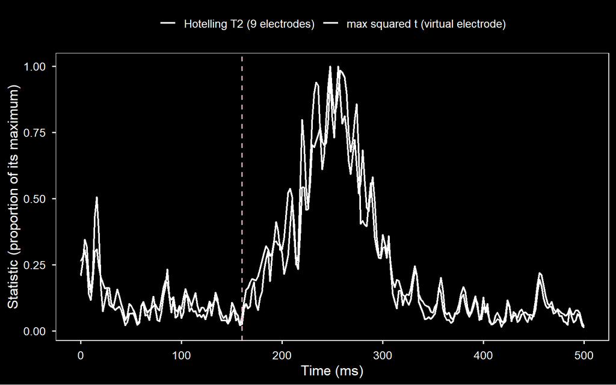

Figure 1: The two ways of reducing nine electrodes to one time course, each scaled by its own maximum. The pink dashed line is the true onset at 160 ms.

```r
ggplot(curves, aes(time, value, colour = statistic)) +
  geom_line(linewidth = 0.8) +
  geom_vline(xintercept = true_onset, linetype = "dashed", colour = "#ffb3c6", linewidth = 0.7) +
  labs(x = "Time (ms)", y = "Statistic (proportion of its maximum)", colour = NULL) +
  scale_colour_bw() +
  theme_dark_bw() +
  theme(legend.position = "top")
```

## 3.5 Observations

# 4 Onsets from the T-squared curve

## 4.1 Description

The curve is a single time course, so the three families of method from `sim.notebook.qmd` apply directly, with no summary across electrodes needed:

- FDR, Benjamini-Hochberg and Benjamini-Yekutieli, across time points, using the exact F transformation of T-squared to obtain a p-value at each time point, then the first significant point.
- MAX correction, taking the 95th percentile of the permutation distribution of the largest T-squared across time, then the first crossing.
- change point on the T-squared curve, by binary segmentation as implemented in the `changepoint` package (Killick & Eckley, 2014).

## 4.2 Justification

The search space has shrunk. In `sim.notebook.qmd` the FDR and MAX corrections cover 251 time points times nine electrodes; here the electrodes are inside the statistic, so the correction covers 251 time points only, and a smaller search space means a less severe correction. That gain is not free: the multivariate statistic spends nine degrees of freedom where a single electrode spends one, so its sensitivity at any given time point is lower than that of the strongest electrode. Which effect dominates is an empirical question.

The permutation is also harder to get wrong. In the univariate case one shared shuffle has to be applied deliberately across all electrodes, since electrodes are correlated and the resampling must not break that structure. Here a trial is a nine-element vector, so permuting trial labels moves the whole vector at once and the structure is preserved by construction.

Benjamini-Yekutieli is reported alongside Benjamini-Hochberg for the same reason as in `sim.notebook.qmd`: adjacent time points are strongly dependent, and BY remains valid under arbitrary dependence where BH does not.

## 4.3 Code

```r
nperm       <- 1000      # permutations for the MAX threshold, low on purpose:
                        # see the note on cost below
cpd_penalty <- "MBIC"   # change point penalty
sig_level   <- 0.05     # significance level for the FDR methods

# helpers that turn a time course into an onset in ms
cp_onset <- function(series, penalty = cpd_penalty){
  tryCatch({
    cp  <- cpt.meanvar(series, method = "BinSeg", Q = 2, penalty = penalty, minseglen = 2)
    pts <- cpts(cp)
    # earliest of the two change points, whatever order cpts() returns them in
    if(length(pts) == 0) NA_real_ else Xf[min(pts)]
  }, error = function(e) NA_real_)
}
first_cross <- function(series, thr){
  s <- which(series > thr); if(length(s) == 0) NA_real_ else Xf[s[1]]
}
first_sig <- function(pcol, level = sig_level){
  s <- which(pcol < level); if(length(s) == 0) NA_real_ else Xf[s[1]]
}

# onsets from one T2 curve, given the arrays it came from
mv_onsets <- function(A, B, nperm = nperm){
  nf <- dim(A)[1]; nA <- dim(A)[2]; nB <- dim(B)[2]; p <- dim(A)[3]

  t2 <- hotelling_t2(A, B)
  pv <- hotelling_p(t2, nA, nB, p)

  # permutation null: shuffle trial labels, keeping each trial's nine values
  # together, and save the largest T2 across time
  pool <- array(0, dim = c(nf, nA + nB, p))
  pool[, 1:nA, ]              <- A
  pool[, (nA + 1):(nA + nB), ] <- B

  null_max <- numeric(nperm)
  for(b in 1:nperm){
    perm <- sample(nA + nB)
    null_max[b] <- max(hotelling_t2(pool[, perm[1:nA], , drop = FALSE],
                                    pool[, perm[(nA + 1):(nA + nB)], , drop = FALSE]),
                       na.rm = TRUE)
  }
  thr <- quantile(null_max, 0.95, names = FALSE)

  tibble(method = c("Hotelling FDR BH", "Hotelling FDR BY",
                    "Hotelling MAX", "Hotelling CPD"),
         onset  = c(first_sig(p.adjust(pv, "BH")),
                    first_sig(p.adjust(pv, "BY")),
                    first_cross(t2, thr),
                    cp_onset(t2)))
}
```

## 4.4 Table

```r
set.seed(11)
mv_onsets(ex$A, ex$B, nperm = nperm) |> knitr::kable()
```

Table 1: Onset (ms) from the Hotelling T-squared curve, one simulated experiment, by each of the four methods.

| method | onset |
| --- | --- |
| Hotelling FDR BH | 2 |
| Hotelling FDR BY | 194 |
| Hotelling MAX | 204 |
| Hotelling CPD | 178 |

## 4.5 Observations

On this run Benjamini-Hochberg returns 2 ms, the first time point of the epoch, which is a false positive rather than an estimate. Benjamini-Yekutieli gives 194 ms, the MAX threshold 204 ms and change point 178 ms, all later than the true 160 ms. Benjamini-Yekutieli is later than Benjamini-Hochberg, as its more conservative correction implies.

# 5 Simulation results (10,000 iterations)

## 5.1 Description

One experiment says little, so performance is evaluated over 10,000 Monte Carlo iterations with 50 trials per condition. The completed simulation is loaded from the saved result file rather than regenerated when this notebook is rendered.

## 5.2 Justification

Using the saved production run keeps the analysis reproducible without repeating the computationally expensive permutation simulation during rendering. The four methods are therefore evaluated from the same 10,000 completed multivariate experiments.

## 5.3 Code

```r
# Load the completed multivariate simulation output.
mv_file <- if(file.exists("data/simres_n50_mult.RData")) {
  "data/simres_n50_mult.RData"
} else {
  "simres_n50_mult.RData"
}

load(mv_file)

# Standardise the saved result table if necessary.
if(exists("sim_mv")) {
  sim_mv <- as_tibble(sim_mv)
} else {
  objs <- mget(ls(), inherits = FALSE)
  hits <- objs[vapply(objs, function(x)
    is.data.frame(x) &&
      all(c("iter", "method", "onset") %in% names(x)), logical(1))]
  if(length(hits) != 1) stop("Could not identify the saved multivariate result table.")
  sim_mv <- as_tibble(hits[[1]])
}

stopifnot(max(sim_mv$iter, na.rm = TRUE) == 10000)

mv_methods <- c("Hotelling FDR BH", "Hotelling FDR BY",
                "Hotelling MAX", "Hotelling CPD")

sim_mv <- sim_mv |>
  mutate(method = factor(method, levels = mv_methods))

method_summary_mv <- sim_mv |>
  group_by(method) |>
  summarise(
    median_onset = median(onset, na.rm = TRUE),
    bias = round(median_onset - true_onset, 1),
    mae = round(mean(abs(onset - true_onset), na.rm = TRUE), 1),
    sd_onset = round(sd(onset, na.rm = TRUE), 1),
    underestimation = round(100 * mean(onset < true_onset, na.rm = TRUE), 1),
    n_missing = sum(is.na(onset)),
    .groups = "drop"
  )
```

## 5.4 Table

```r
method_summary_mv |>
  rename(
    `Method` = method,
    `Median onset (ms)` = median_onset,
    `Bias (ms)` = bias,
    `MAE (ms)` = mae,
    `SD (ms)` = sd_onset,
    `Underestimation (%)` = underestimation,
    `No onset (n)` = n_missing
  ) |>
  knitr::kable()
```

Table 2: Performance of the four multivariate strategies across 10,000 simulations with 50 trials per condition.

| Method | Median onset (ms) | Bias (ms) | MAE (ms) | SD (ms) | Underestimation (%) | No onset (n) |
| --- | --- | --- | --- | --- | --- | --- |
| Hotelling FDR BH | 180 | 20 | 53.5 | 65.7 | 39.6 | 0 |
| Hotelling FDR BY | 196 | 36 | 41.4 | 38.0 | 8.8 | 0 |
| Hotelling MAX | 202 | 42 | 43.7 | 20.8 | 1.9 | 0 |
| Hotelling CPD | 186 | 26 | 26.5 | 11.4 | 1.6 | 0 |

## 5.5 Figure

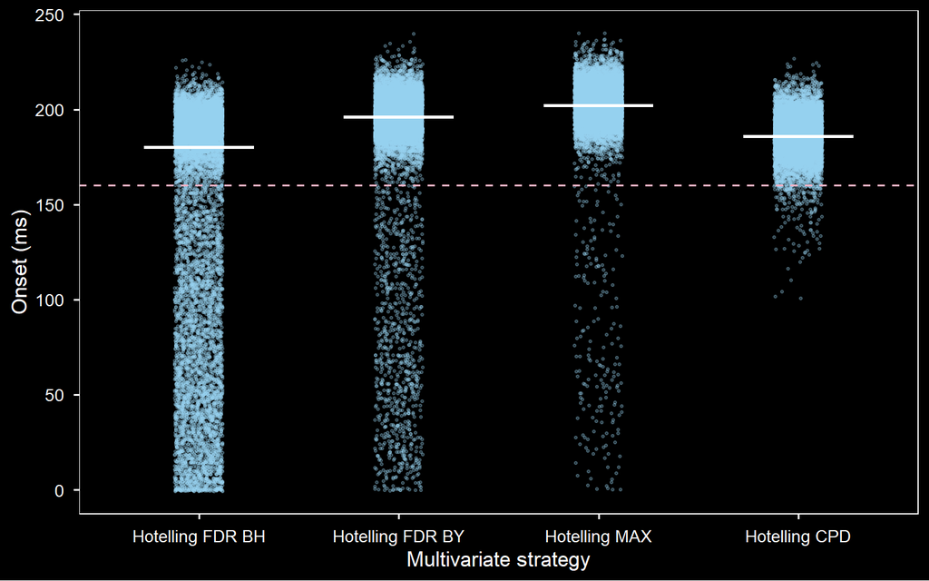

Figure 2: Onset distributions by multivariate strategy across 10,000 simulations. The white horizontal line is the median and the pink dashed line marks the true onset at 160 ms.

```r
ggplot(sim_mv, aes(method, onset)) +
  geom_jitter(width = 0.12, alpha = 0.25, size = 0.7, colour = "#96d2f0") +
  stat_summary(fun = median, fun.min = median, fun.max = median,
               geom = "crossbar", width = 0.55, linewidth = 0.4, colour = "#ffffff") +
  geom_hline(yintercept = true_onset, linetype = "dashed", colour = "#ffb3c6", linewidth = 0.7) +
  labs(x = "Multivariate strategy", y = "Onset (ms)") +
  theme_dark_bw()
```

# 6 Discussion and next steps

This simulation is not built to favour the multivariate test, and two features of it work directly against the test. Both belong in any reading of the results.

The first is the noise. Hotelling’s T-squared earns its advantage over separate univariate tests by using the covariance between electrodes: when the noise is correlated across electrodes but the effect is not, the test can separate the two. In this simulation the noise is generated independently at every electrode, so the true covariance matrix is close to diagonal and there is little structure for the test to exploit. What it estimates instead is sampling noise in a nine by nine matrix, from 100 trials. The design was chosen in the demo as the harder case for the univariate methods, but it is also the case in which the multivariate test has least to offer. A version with noise shared across neighbouring electrodes would be a fairer test of it, and is the obvious follow-up.

The second is dilution. Four of the nine electrodes carry no signal at all. Hotelling’s T-squared spends degrees of freedom on all nine dimensions regardless, so those four contribute variance without contributing effect, and the statistic is weaker than it would be with only the five signal electrodes. This is the same electrode-selection problem as in `sim.notebook.qmd`, arriving from a different direction: there it decided which onsets to summarise, here it decides which dimensions enter the test. The remedies are the same, an a priori region of interest or a data-driven selection step, and neither is free.

Against those disadvantages sits one clear advantage: the correction covers 251 time points instead of 251 times nine, and the permutation cannot break the correlation structure, since it moves whole trials. Comparable performance in a design tilted against the test would therefore be a stronger result than the raw numbers suggest.

Next steps:

- fold the T-squared curve into `sim.notebook.qmd` as four further strategies, so that the multivariate and univariate methods are compared on the same runs rather than across notebooks.
- repeat with noise shared across neighbouring electrodes, which is the case the multivariate test is designed for.
- try a linear discriminant analysis across electrodes as an alternative multivariate statistic, which does not rest on a common covariance in the same way.
- test the effect of restricting the test to a subset of electrodes, to separate the dilution problem from the noise problem.

# 7 References

- Benjamini, Y., & Hochberg, Y. (1995). Controlling the false discovery rate: A practical and powerful approach to multiple testing. *Journal of the Royal Statistical Society: Series B, 57*(1), 289-300. https://doi.org/10.1111/j.2517-6161.1995.tb02031.x
- Benjamini, Y., & Yekutieli, D. (2001). The control of the false discovery rate in multiple testing under dependency. *The Annals of Statistics, 29*(4), 1165-1188. https://doi.org/10.1214/aos/1013699998
- Hotelling, H. (1931). The generalization of Student’s ratio. *The Annals of Mathematical Statistics, 2*(3), 360-378. https://doi.org/10.1214/aoms/1177732979
- Killick, R., & Eckley, I. A. (2014). changepoint: An R package for changepoint analysis. *Journal of Statistical Software, 58*(3), 1-19. https://doi.org/10.18637/jss.v058.i03
- Rousselet, G. A. (2025). Using cluster-based permutation tests to estimate MEG/EEG onsets: How bad is it? *European Journal of Neuroscience, 61*(1), e16618. https://doi.org/10.1111/ejn.16618